# Optimal Treatment Analysis

## Outcome Variable

**Outcome Variable:** haz

## Predictor Variables

**Intervention Variable:** parity

**Adjustment Set:**

- arm
- W_mage
- meducyrs
- feducyrs
- hhwealth_quart
- W_mhtcm
- W_mwtkg
- W_mbmi
- vagbrth
- W_nrooms
- impsan
- delta_W_mage
- delta_meducyrs
- delta_feducyrs
- delta_hhwealth_quart
- delta_W_mhtcm
- delta_W_mwtkg
- delta_W_mbmi
- delta_vagbrth
- delta_W_nrooms
- delta_impsan

## Stratifying Variables

The analysis was stratified on these variable(s):

- agecat
- studyid
- country

## Data Summary

| agecat | studyid | country | parity | n_cell | n |
| --- | --- | --- | --- | --- | --- |
| Birth | ki1000304b-SAS-CompFeed | INDIA | 1 | 361 | 1252 |
| Birth | ki1000304b-SAS-CompFeed | INDIA | 2 | 289 | 1252 |
| Birth | ki1000304b-SAS-CompFeed | INDIA | 3+ | 602 | 1252 |
| Birth | ki1017093b-PROVIDE | BANGLADESH | 1 | 206 | 539 |
| Birth | ki1017093b-PROVIDE | BANGLADESH | 2 | 183 | 539 |
| Birth | ki1017093b-PROVIDE | BANGLADESH | 3+ | 150 | 539 |
| Birth | ki1101329-Keneba | GAMBIA | 1 | 156 | 1407 |
| Birth | ki1101329-Keneba | GAMBIA | 2 | 146 | 1407 |
| Birth | ki1101329-Keneba | GAMBIA | 3+ | 1105 | 1407 |
| Birth | ki1113344-GMS-Nepal | NEPAL | 1 | 211 | 696 |
| Birth | ki1113344-GMS-Nepal | NEPAL | 2 | 180 | 696 |
| Birth | ki1113344-GMS-Nepal | NEPAL | 3+ | 305 | 696 |
| Birth | ki1126311-ZVITAMBO | ZIMBABWE | 1 | 5989 | 13874 |
| Birth | ki1126311-ZVITAMBO | ZIMBABWE | 2 | 4144 | 13874 |
| Birth | ki1126311-ZVITAMBO | ZIMBABWE | 3+ | 3741 | 13874 |
| Birth | ki1135781-COHORTS | GUATEMALA | 1 | 112 | 852 |
| Birth | ki1135781-COHORTS | GUATEMALA | 2 | 137 | 852 |
| Birth | ki1135781-COHORTS | GUATEMALA | 3+ | 603 | 852 |
| Birth | ki1135781-COHORTS | INDIA | 1 | 696 | 4122 |
| Birth | ki1135781-COHORTS | INDIA | 2 | 1037 | 4122 |
| Birth | ki1135781-COHORTS | INDIA | 3+ | 2389 | 4122 |
| Birth | ki1135781-COHORTS | PHILIPPINES | 1 | 675 | 3050 |
| Birth | ki1135781-COHORTS | PHILIPPINES | 2 | 687 | 3050 |
| Birth | ki1135781-COHORTS | PHILIPPINES | 3+ | 1688 | 3050 |
| Birth | kiGH5241-JiVitA-3 | BANGLADESH | 1 | 9915 | 26667 |
| Birth | kiGH5241-JiVitA-3 | BANGLADESH | 2 | 8878 | 26667 |
| Birth | kiGH5241-JiVitA-3 | BANGLADESH | 3+ | 7874 | 26667 |
| 6 months | ki1000304b-SAS-CompFeed | INDIA | 1 | 392 | 1336 |
| 6 months | ki1000304b-SAS-CompFeed | INDIA | 2 | 304 | 1336 |
| 6 months | ki1000304b-SAS-CompFeed | INDIA | 3+ | 640 | 1336 |

[output cut: 57 more lines]

The following strata were considered:

- agecat: 24 months, studyid: ki1017093b-PROVIDE, country: BANGLADESH
- agecat: 24 months, studyid: ki1066203-TanzaniaChild2, country: TANZANIA, UNITED REPUBLIC OF
- agecat: 24 months, studyid: ki1101329-Keneba, country: GAMBIA
- agecat: 24 months, studyid: ki1113344-GMS-Nepal, country: NEPAL
- agecat: 24 months, studyid: ki1126311-ZVITAMBO, country: ZIMBABWE
- agecat: 24 months, studyid: ki1135781-COHORTS, country: GUATEMALA
- agecat: 24 months, studyid: ki1135781-COHORTS, country: INDIA
- agecat: 24 months, studyid: ki1135781-COHORTS, country: PHILIPPINES
- agecat: 24 months, studyid: kiGH5241-JiVitA-3, country: BANGLADESH
- agecat: 6 months, studyid: ki1000304b-SAS-CompFeed, country: INDIA
- agecat: 6 months, studyid: ki1000304b-SAS-FoodSuppl, country: INDIA
- agecat: 6 months, studyid: ki1017093b-PROVIDE, country: BANGLADESH
- agecat: 6 months, studyid: ki1066203-TanzaniaChild2, country: TANZANIA, UNITED REPUBLIC OF
- agecat: 6 months, studyid: ki1101329-Keneba, country: GAMBIA
- agecat: 6 months, studyid: ki1113344-GMS-Nepal, country: NEPAL
- agecat: 6 months, studyid: ki1126311-ZVITAMBO, country: ZIMBABWE
- agecat: 6 months, studyid: ki1135781-COHORTS, country: GUATEMALA
- agecat: 6 months, studyid: ki1135781-COHORTS, country: INDIA
- agecat: 6 months, studyid: ki1135781-COHORTS, country: PHILIPPINES
- agecat: 6 months, studyid: kiGH5241-JiVitA-3, country: BANGLADESH
- agecat: Birth, studyid: ki1000304b-SAS-CompFeed, country: INDIA
- agecat: Birth, studyid: ki1017093b-PROVIDE, country: BANGLADESH
- agecat: Birth, studyid: ki1101329-Keneba, country: GAMBIA
- agecat: Birth, studyid: ki1113344-GMS-Nepal, country: NEPAL
- agecat: Birth, studyid: ki1126311-ZVITAMBO, country: ZIMBABWE
- agecat: Birth, studyid: ki1135781-COHORTS, country: GUATEMALA
- agecat: Birth, studyid: ki1135781-COHORTS, country: INDIA
- agecat: Birth, studyid: ki1135781-COHORTS, country: PHILIPPINES
- agecat: Birth, studyid: kiGH5241-JiVitA-3, country: BANGLADESH

### Dropped Strata

Some strata were dropped due to rare outcomes:

- agecat: 24 months, studyid: ki1066203-TanzaniaChild2, country: TANZANIA, UNITED REPUBLIC OF

## Methods Detail

We’re interested in the causal parameters $E[Y_a]$ for all values of $a \in \mathcal{A}$. These parameters represent the mean outcome if, possibly contrary to fact, we intervened to set all units to have $A=a$. Under the randomization and positivity assumptions, these are identified by the statistical parameters $\psi_a=E_W[E_{Y|A,W}(Y|A=a,W)]$. In addition, we’re interested in the mean of $Y$, $E[Y]$ under no intervention (the observed mean). We will estimate these parameters by using SuperLearner to fit the relevant likelihood factors – $E_{Y|A,W}(Y|A=a,W)$ and $p(A=a|W)$, and then updating our likelihood fit using a joint TMLE.

For unadjusted analyses ($W=\{\}$), initial likelihoods were estimated using Lrnr_glm to estimate the simple $E(Y|A)$ and Lrnr_mean to estimate $p(A)$. For adjusted analyses, a small library containing Lrnr_glmnet, Lrnr_xgboost, and Lrnr_mean was used.

Having estimated these parameters, we will then use the delta method to estimate relative risks and attributable risks relative to a prespecified baseline level of $A$.

# Results Detail

## Results Plots

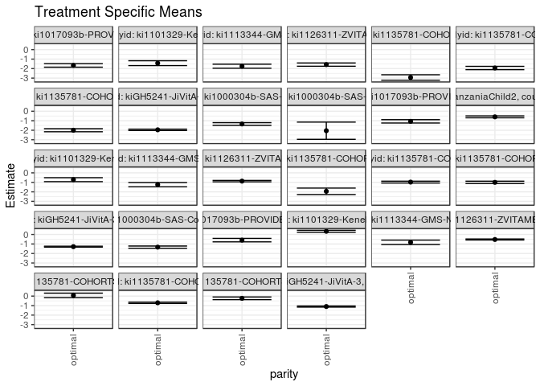

## Results Table

### Parameter: TSM

| agecat | studyid | country | intervention_level | baseline_level | estimate | ci_lower | ci_upper |
| --- | --- | --- | --- | --- | --- | --- | --- |
| Birth | ki1000304b-SAS-CompFeed | INDIA | optimal | observed | -1.3328737 | -1.4504364 | -1.2153111 |
| Birth | ki1017093b-PROVIDE | BANGLADESH | optimal | observed | -0.5954620 | -0.7789169 | -0.4120071 |
| Birth | ki1101329-Keneba | GAMBIA | optimal | observed | 0.3328223 | 0.2251774 | 0.4404672 |
| Birth | ki1113344-GMS-Nepal | NEPAL | optimal | observed | -0.8252648 | -1.0592331 | -0.5912965 |
| Birth | ki1126311-ZVITAMBO | ZIMBABWE | optimal | observed | -0.5275347 | -0.5812784 | -0.4737910 |
| Birth | ki1135781-COHORTS | GUATEMALA | optimal | observed | 0.0745285 | -0.1606056 | 0.3096626 |
| Birth | ki1135781-COHORTS | INDIA | optimal | observed | -0.7038638 | -0.7715920 | -0.6361355 |
| Birth | ki1135781-COHORTS | PHILIPPINES | optimal | observed | -0.2333096 | -0.3743677 | -0.0922515 |
| Birth | kiGH5241-JiVitA-3 | BANGLADESH | optimal | observed | -1.0972960 | -1.1559237 | -1.0386683 |
| 6 months | ki1000304b-SAS-CompFeed | INDIA | optimal | observed | -1.3407071 | -1.4788010 | -1.2026133 |
| 6 months | ki1000304b-SAS-FoodSuppl | INDIA | optimal | observed | -2.0515090 | -2.9584787 | -1.1445394 |
| 6 months | ki1017093b-PROVIDE | BANGLADESH | optimal | observed | -1.0646876 | -1.2421161 | -0.8872590 |
| 6 months | ki1066203-TanzaniaChild2 | TANZANIA, UNITED REPUBLIC OF | optimal | observed | -0.5912825 | -0.6931553 | -0.4894098 |
| 6 months | ki1101329-Keneba | GAMBIA | optimal | observed | -0.7196243 | -0.9280483 | -0.5112003 |
| 6 months | ki1113344-GMS-Nepal | NEPAL | optimal | observed | -1.2435036 | -1.4685103 | -1.0184969 |
| 6 months | ki1126311-ZVITAMBO | ZIMBABWE | optimal | observed | -0.8694890 | -0.9423913 | -0.7965868 |
| 6 months | ki1135781-COHORTS | GUATEMALA | optimal | observed | -1.9418963 | -2.2801115 | -1.6036811 |
| 6 months | ki1135781-COHORTS | INDIA | optimal | observed | -0.9734899 | -1.0703142 | -0.8766656 |
| 6 months | ki1135781-COHORTS | PHILIPPINES | optimal | observed | -1.0013840 | -1.1237059 | -0.8790620 |
| 6 months | kiGH5241-JiVitA-3 | BANGLADESH | optimal | observed | -1.2824496 | -1.3283175 | -1.2365816 |
| 24 months | ki1017093b-PROVIDE | BANGLADESH | optimal | observed | -1.6640639 | -1.8490988 | -1.4790289 |
| 24 months | ki1101329-Keneba | GAMBIA | optimal | observed | -1.4262284 | -1.6810293 | -1.1714275 |
| 24 months | ki1113344-GMS-Nepal | NEPAL | optimal | observed | -1.7461442 | -1.9598386 | -1.5324497 |
| 24 months | ki1126311-ZVITAMBO | ZIMBABWE | optimal | observed | -1.5782533 | -1.7494444 | -1.4070621 |
| 24 months | ki1135781-COHORTS | GUATEMALA | optimal | observed | -2.9349717 | -3.2228716 | -2.6470718 |
| 24 months | ki1135781-COHORTS | INDIA | optimal | observed | -1.9342663 | -2.1082461 | -1.7602865 |
| 24 months | ki1135781-COHORTS | PHILIPPINES | optimal | observed | -2.0006915 | -2.1605106 | -1.8408725 |
| 24 months | kiGH5241-JiVitA-3 | BANGLADESH | optimal | observed | -1.9554063 | -2.0263865 | -1.8844260 |

### Parameter: E(Y)

| agecat | studyid | country | intervention_level | baseline_level | estimate | ci_lower | ci_upper |
| --- | --- | --- | --- | --- | --- | --- | --- |
| Birth | ki1000304b-SAS-CompFeed | INDIA | observed | observed | -1.4314217 | -1.5099245 | -1.3529189 |
| Birth | ki1017093b-PROVIDE | BANGLADESH | observed | observed | -0.8851020 | -0.9601332 | -0.8100709 |
| Birth | ki1101329-Keneba | GAMBIA | observed | observed | 0.0483298 | -0.0182746 | 0.1149342 |
| Birth | ki1113344-GMS-Nepal | NEPAL | observed | observed | -1.0851580 | -1.1651811 | -1.0051350 |
| Birth | ki1126311-ZVITAMBO | ZIMBABWE | observed | observed | -0.5003222 | -0.5208673 | -0.4797770 |
| Birth | ki1135781-COHORTS | GUATEMALA | observed | observed | 0.1297300 | 0.0458017 | 0.2136584 |
| Birth | ki1135781-COHORTS | INDIA | observed | observed | -0.6773241 | -0.7124609 | -0.6421873 |
| Birth | ki1135781-COHORTS | PHILIPPINES | observed | observed | -0.2490492 | -0.2880580 | -0.2100404 |
| Birth | kiGH5241-JiVitA-3 | BANGLADESH | observed | observed | -1.1729576 | -1.2009629 | -1.1449523 |
| 6 months | ki1000304b-SAS-CompFeed | INDIA | observed | observed | -1.4018563 | -1.4810585 | -1.3226541 |
| 6 months | ki1000304b-SAS-FoodSuppl | INDIA | observed | observed | -1.8986842 | -2.0118892 | -1.7854792 |
| 6 months | ki1017093b-PROVIDE | BANGLADESH | observed | observed | -1.0916915 | -1.1661176 | -1.0172654 |
| 6 months | ki1066203-TanzaniaChild2 | TANZANIA, UNITED REPUBLIC OF | observed | observed | -0.5432778 | -0.5926218 | -0.4939338 |
| 6 months | ki1101329-Keneba | GAMBIA | observed | observed | -0.9239386 | -0.9768148 | -0.8710623 |
| 6 months | ki1113344-GMS-Nepal | NEPAL | observed | observed | -1.3508392 | -1.4290633 | -1.2726152 |
| 6 months | ki1126311-ZVITAMBO | ZIMBABWE | observed | observed | -0.8679886 | -0.8935535 | -0.8424236 |
| 6 months | ki1135781-COHORTS | GUATEMALA | observed | observed | -1.8157336 | -1.8837688 | -1.7476985 |
| 6 months | ki1135781-COHORTS | INDIA | observed | observed | -1.0455022 | -1.0805318 | -1.0104727 |
| 6 months | ki1135781-COHORTS | PHILIPPINES | observed | observed | -1.1405724 | -1.1824954 | -1.0986493 |
| 6 months | kiGH5241-JiVitA-3 | BANGLADESH | observed | observed | -1.3355900 | -1.3586765 | -1.3125035 |
| 24 months | ki1017093b-PROVIDE | BANGLADESH | observed | observed | -1.6024221 | -1.6857420 | -1.5191023 |
| 24 months | ki1101329-Keneba | GAMBIA | observed | observed | -1.5883084 | -1.6443765 | -1.5322402 |
| 24 months | ki1113344-GMS-Nepal | NEPAL | observed | observed | -1.8874180 | -1.9728588 | -1.8019773 |
| 24 months | ki1126311-ZVITAMBO | ZIMBABWE | observed | observed | -1.6059640 | -1.6629797 | -1.5489484 |
| 24 months | ki1135781-COHORTS | GUATEMALA | observed | observed | -2.9905921 | -3.0548289 | -2.9263553 |
| 24 months | ki1135781-COHORTS | INDIA | observed | observed | -2.2397574 | -2.2808841 | -2.1986307 |
| 24 months | ki1135781-COHORTS | PHILIPPINES | observed | observed | -2.4141145 | -2.4590818 | -2.3691473 |
| 24 months | kiGH5241-JiVitA-3 | BANGLADESH | observed | observed | -2.0195844 | -2.0472504 | -1.9919183 |

### Parameter: PAR

| agecat | studyid | country | intervention_level | baseline_level | estimate | ci_lower | ci_upper |
| --- | --- | --- | --- | --- | --- | --- | --- |
| Birth | ki1000304b-SAS-CompFeed | INDIA | optimal | observed | -0.0985480 | -0.1923205 | -0.0047755 |
| Birth | ki1017093b-PROVIDE | BANGLADESH | optimal | observed | -0.2896400 | -0.4569355 | -0.1223446 |
| Birth | ki1101329-Keneba | GAMBIA | optimal | observed | -0.2844925 | -0.3834265 | -0.1855586 |
| Birth | ki1113344-GMS-Nepal | NEPAL | optimal | observed | -0.2598933 | -0.4832739 | -0.0365126 |
| Birth | ki1126311-ZVITAMBO | ZIMBABWE | optimal | observed | 0.0272126 | -0.0223480 | 0.0767731 |
| Birth | ki1135781-COHORTS | GUATEMALA | optimal | observed | 0.0552015 | -0.1618343 | 0.2722374 |
| Birth | ki1135781-COHORTS | INDIA | optimal | observed | 0.0265397 | -0.0322442 | 0.0853235 |
| Birth | ki1135781-COHORTS | PHILIPPINES | optimal | observed | -0.0157396 | -0.1494645 | 0.1179854 |
| Birth | kiGH5241-JiVitA-3 | BANGLADESH | optimal | observed | -0.0756616 | -0.1290624 | -0.0222608 |
| 6 months | ki1000304b-SAS-CompFeed | INDIA | optimal | observed | -0.0611492 | -0.1638626 | 0.0415643 |
| 6 months | ki1000304b-SAS-FoodSuppl | INDIA | optimal | observed | 0.1528248 | -0.7211707 | 1.0268204 |
| 6 months | ki1017093b-PROVIDE | BANGLADESH | optimal | observed | -0.0270039 | -0.1889206 | 0.1349127 |
| 6 months | ki1066203-TanzaniaChild2 | TANZANIA, UNITED REPUBLIC OF | optimal | observed | 0.0480048 | -0.0394262 | 0.1354357 |
| 6 months | ki1101329-Keneba | GAMBIA | optimal | observed | -0.2043142 | -0.4085411 | -0.0000873 |
| 6 months | ki1113344-GMS-Nepal | NEPAL | optimal | observed | -0.1073356 | -0.3190800 | 0.1044088 |
| 6 months | ki1126311-ZVITAMBO | ZIMBABWE | optimal | observed | 0.0015005 | -0.0663556 | 0.0693565 |
| 6 months | ki1135781-COHORTS | GUATEMALA | optimal | observed | 0.1261627 | -0.2006374 | 0.4529628 |
| 6 months | ki1135781-COHORTS | INDIA | optimal | observed | -0.0720123 | -0.1631138 | 0.0190893 |
| 6 months | ki1135781-COHORTS | PHILIPPINES | optimal | observed | -0.1391884 | -0.2546744 | -0.0237024 |
| 6 months | kiGH5241-JiVitA-3 | BANGLADESH | optimal | observed | -0.0531405 | -0.0942904 | -0.0119906 |
| 24 months | ki1017093b-PROVIDE | BANGLADESH | optimal | observed | 0.0616417 | -0.1028028 | 0.2260862 |
| 24 months | ki1101329-Keneba | GAMBIA | optimal | observed | -0.1620800 | -0.4129038 | 0.0887439 |
| 24 months | ki1113344-GMS-Nepal | NEPAL | optimal | observed | -0.1412738 | -0.3403894 | 0.0578417 |
| 24 months | ki1126311-ZVITAMBO | ZIMBABWE | optimal | observed | -0.0277107 | -0.1856378 | 0.1302163 |
| 24 months | ki1135781-COHORTS | GUATEMALA | optimal | observed | -0.0556204 | -0.3323414 | 0.2211006 |
| 24 months | ki1135781-COHORTS | INDIA | optimal | observed | -0.3054911 | -0.4739237 | -0.1370584 |
| 24 months | ki1135781-COHORTS | PHILIPPINES | optimal | observed | -0.4134230 | -0.5686148 | -0.2582311 |
| 24 months | kiGH5241-JiVitA-3 | BANGLADESH | optimal | observed | -0.0641781 | -0.1294098 | 0.0010536 |